# danjtan_8

Dan Tanner

19 March, 2017

# Exercise 1

*Try to use the following data set to execute ANCOVA and make interaction plots. This data set contains the fruit weight (`Fruit`) of different plants with different root depth (`Root`) and different treatment (`Grazing`).*

```r
gz = read.table(text=getURL("https://raw.githubusercontent.com/OscarFHC/NRE538_GSRA/master/Labs/NRE538_ANCOVA_n_Interaction/ipomopsis.txt"), sep="", header=T,comment.char="#")
```

We start out by visualizing the data:

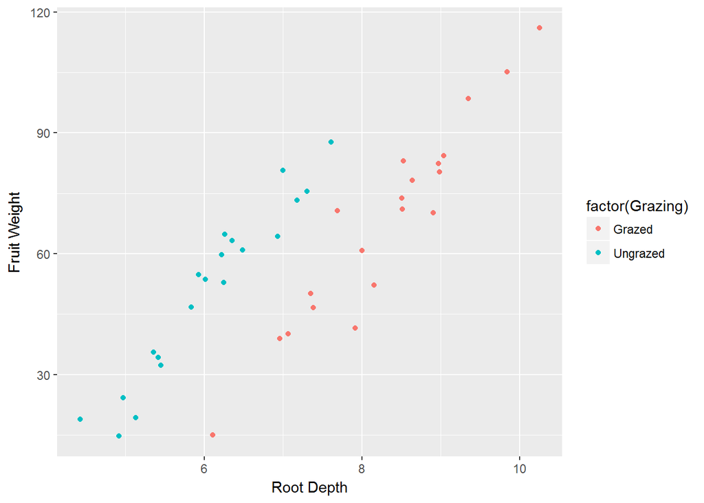

```r
ggplot(data=gz, mapping=aes(x=Root, y=Fruit, color=factor(Grazing)))+
  geom_point() + labs(x= "Root Depth", y = "Fruit Weight")
```

Looks like we’re going to have good linear fits. Let’s check for normality:

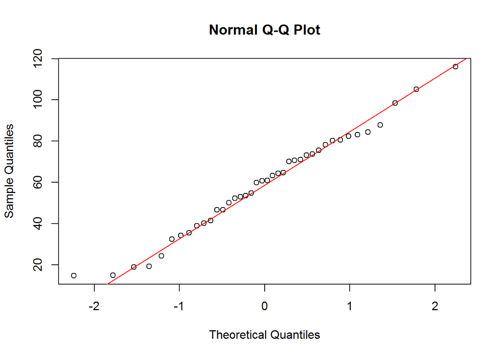

```r
qqnorm(gz$Fruit)
qqline(gz$Fruit, col="red")
```

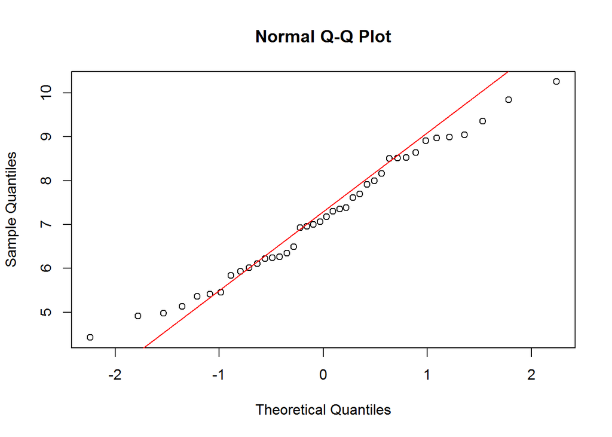

```r
qqnorm(gz$Root)
qqline(gz$Root, col="red")
```

Doesn’t look great, but we’ll roll with it.

```r
mod.fruit <- lm(Fruit~Root * Grazing, data = gz)
```

[figure not shown]

```r
interplot(m=mod.fruit, var1="Root", var2="Grazing")+
  labs(x="League ID", y="Estimated coefficient for Root Length", title="Estimated Coefficient of Root Length on Grazing")
```

It looks like the coefficient is higher for ungrazed plants, meaning that the effect of root length on fruit harvest is greater for ungrazed plants. However, the confidence intervals overlap, so the differece that we are seeing cannot be assumed to be significant.

```r
summary(mod.fruit)$coefficients
```

```
##                          Estimate Std. Error    t value     Pr(>|t|)
## (Intercept)          -125.1730569  12.811165 -9.7706222 1.150540e-11
## Root                   23.2403732   1.530771 15.1821314 3.173208e-17
## GrazingUngrazed        30.8057049  16.841823  1.8291194 7.567489e-02
## Root:GrazingUngrazed    0.7560338   2.354111  0.3211547 7.499503e-01
```

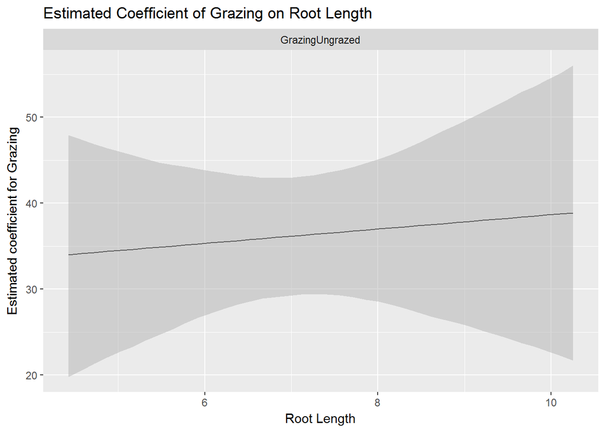

```r
interplot(m=mod.fruit, var1="Grazing", var2="Root")+
  labs(x="Root Length", y="Estimated coefficient for Grazing", title="Estimated Coefficient of Grazing on Root Length")
```

Here we see that the interaction effect detected is slight, but suggests that for ungrazed plants, the root length has a stronger effect on fruit harvest than the effect for grazed plants. Referring to our above sumamry coefficients, however, we see a p-value of ~0.75 which is not significant. Thus we cannot assume there is a significant interaction between grazing and root length.

# Exercise 2

## Part 1

*Use F-test to compare mod.1 and mod.2. Explain why you chose one over another to explain the data.*

```r
data("airquality")
mod1 = lm(Temp~Wind + Ozone, data=airquality) #no interaction term
mod2 = lm(Temp~Wind * Ozone, data=airquality) #interaction term included
```

F-Test:

```r
anova(mod1, mod2)
```

```
## Analysis of Variance Table
##
## Model 1: Temp ~ Wind + Ozone
## Model 2: Temp ~ Wind * Ozone
##   Res.Df    RSS Df Sum of Sq      F    Pr(>F)
## 1    113 5166.5
## 2    112 4482.7  1    683.81 17.085 6.927e-05 ***
## ---
## Signif. codes:  0 '***' 0.001 '**' 0.01 '*' 0.05 '.' 0.1 ' ' 1
```

From this summary table we see the RSS of mod2 is ~683 lower than the RSS of `mod1`. The F-statistic is 17.085, which gives us a p-value of 6.927e-05. Thus `mod2` explains significantly more variance in our data, since the probability of `mod1` explaining the same amount of variance is 0.00006927. We will use mod2, which includes the interaction term.

## Part 2

*Plot two interaction plots with interplot() for the model with wind and solar radiation as the independent variables. Interprete the two interaction plots.*

```r
mod3 <- lm(Temp~Wind * Solar.R, data = airquality)
```

[figure not shown]

```r
interplot(m=mod3, var1="Wind", var2="Solar.R")+
  labs(x="Wind", y="Coefficient for Solar Radiation", title="Estimated Coefficient of Solar Radiation")
```

[figure not shown]

```r
interplot(m=mod3, var1="Solar.R", var2="Wind")+
  labs(x="Solar Radiation", y="Coefficient for Wind", title="Estimated Coefficient of Wind")
```

```r
summary(mod3)$coefficients
```

```
##                   Estimate  Std. Error    t value     Pr(>|t|)
## (Intercept)  83.5922238443 4.845316775 17.2521690 1.150975e-36
## Wind         -1.0384133265 0.418325835 -2.4823074 1.421876e-02
## Solar.R       0.0328497614 0.023916645  1.3735104 1.717583e-01
## Wind:Solar.R -0.0006491955 0.002065479 -0.3143075 7.537488e-01
```